# 121140068_ho2

## Hands-on 2

by Arsyadana Estu Aziz (121140068)

### Task 1

### Analisis Pengaruh Noise pada Sinyal Sinusoid

**Tujuan:**

- Memahami pengaruh noise terhadap spektrum frekuensi
- Membandingkan performa DFT dan FFT
- Mempelajari visualisasi sinyal dalam domain waktu dan frekuensi

```python
## Install Library
import numpy as np
import matplotlib.pyplot as plt
from scipy import fft, signal
import time
```

```python
## Implementation of scipy_fft
def calculate_scipy_fft(signal, fs):
    """
    Calculate FFT using SciPy's implementation.

    Parameters:
    signal (array): Input time domain signal
    fs (float): Sampling frequency in Hz

    Returns:
    tuple: (frequencies, fft_result)
    """
    N = len(signal)

    # Calculate FFT
    fft_result = fft.fft(signal)

    # Calculate frequency axis
    frequencies = fft.fftfreq(N, d=1/fs)

    return frequencies, fft_result
```

```python
## Implementation of DFT
def calculate_dft(signal):
    """
    Calculate Discrete Fourier Transform (DFT) manually.

    Parameters:
    signal (array): Input time domain signal

    Returns:
    array: Frequency domain representation
    """
    N = len(signal)
    dft = np.zeros(N, dtype=complex)

    for k in range(N):  # Frequency
        for n in range(N):  # Time
            dft[k] += signal[n] * np.exp(-2j * np.pi * k * n / N)

    return dft
```

### Task 1

- Jelaskan pengaruh level noise terhadap:
  - Bentuk sinyal dalam domain waktu
  - Spektrum frekuensi yang dihasilkan
- Pada level noise berapa sinyal asli (10 Hz) masih dapat diidentifikasi dengan jelas?
- Bandingkan waktu komputasi antara DFT dan FFT untuk sinyal ini

```
Scipy FFT time with noise level 0.1: 0.0021 s
DFT time with noise level 0.1: 25.4464 s
Scipy FFT time with noise level 0.5: 0.0000 s
DFT time with noise level 0.5: 20.5106 s
Scipy FFT time with noise level 1.0: 0.0000 s
DFT time with noise level 1.0: 24.6489 s
```

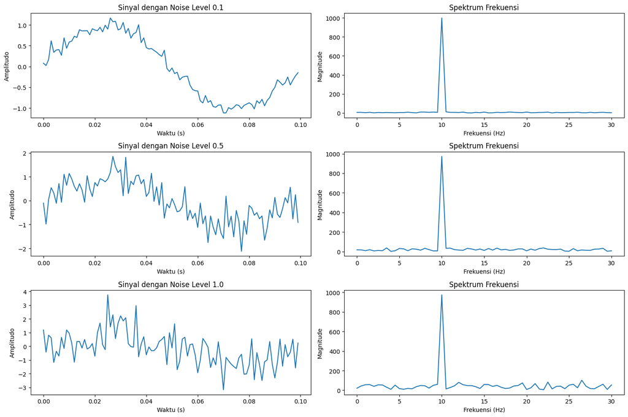

```python
# 1. Buat sinyal sinusoid sederhana
fs = 1000  # sampling frequency
t = np.linspace(0, 2, 2*fs)  # 2 detik sinyal
f1 = 10  # frekuensi 10 Hz
signal = np.sin(2 * np.pi * f1 * t)

# 2. Tambahkan noise dengan berbagai level
noise_levels = [0.1, 0.5, 1.0]  # level noise yang berbeda
plt.figure(figsize=(15, 10))

for i, noise_level in enumerate(noise_levels, 1):
    # Tambahkan noise
    noisy_signal = signal + noise_level * np.random.normal(0, 1, len(t))

    # Hitung FFT and Print the time operation
    start_time = time.time()
    freq, fft_result = calculate_scipy_fft(noisy_signal, fs)
    scipy_fft_time = time.time() - start_time
    print(f"Scipy FFT time with noise level {noise_level}: {scipy_fft_time:.4f} s")


    # Hitung DFT and Print the time operation
    start_time = time.time()
    dft = calculate_dft(noisy_signal)
    dft_time = time.time() - start_time
    print(f"DFT time with noise level {noise_level}: {dft_time:.4f} s")

    # Plot
    plt.subplot(3, 2, 2*i-1)
    plt.plot(t[:100], noisy_signal[:100])  # Plot 100 sampel pertama
    plt.title(f'Sinyal dengan Noise Level {noise_level}')
    plt.xlabel('Waktu (s)')
    plt.ylabel('Amplitudo')

    plt.subplot(3, 2, 2*i)
    freq_mask = (freq >= 0) & (freq <= 30)  # Plot 0-30 Hz
    plt.plot(freq[freq_mask], np.abs(fft_result)[freq_mask])
    plt.title(f'Spektrum Frekuensi')
    plt.xlabel('Frekuensi (Hz)')
    plt.ylabel('Magnitude')

plt.tight_layout()
plt.show()
```